# ReproDataSci

Ruger Carter

2023-03-01

### Database Diagram

This is a diagram of my data. Primary keys are italicized. Foreign keys are bolded.

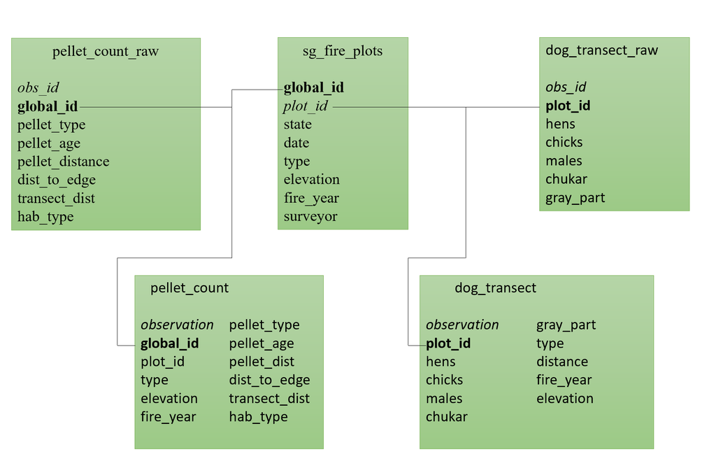

### Creating the database

This is the code I used to create the database. We’ll start with loading the `DBI` and ``RSQLite` Packages.

```r
library(DBI)
library(RSQLite)
```

First, we’re going to start by establishing a connection to a SQLite database.

```r
sg_db <- dbConnect(RSQLite::SQLite(), "sg.db")
```

### Creating the sage-grouse plot data

This table includes all plot data that we sampled using pointing dogs and pellet counts.

```r
#create plot table
dbExecute(sg_db, "CREATE TABLE sg_fire_plots (
          global_id,
          plot_id varchar(5) NOT NULL,
          state varchar(2) CHECK (state IN ('Idaho', 'Utah')),
          date,
          type char (1) CHECK (type IN ('B','C')),
          elevation char (4),
          fire_year char (4),
          surveyor,
          PRIMARY KEY (plot_id)
          );")

sg_fire_plots <- read.csv("Data/raw_data/sg_fire_plots.csv")
names(sg_fire_plots)

#Enter data from CSV into table
dbWriteTable(sg_db, "sg_fire_plots", sg_fire_plots, append = TRUE)
```

This is what the content of the table looks like:

```r
#check data
dbGetQuery(sg_db, "SELECT * FROM sg_fire_plots LIMIT 10;")
```

```
##                               global_id plot_id state            date type
## 1  f8c4c2e7-0943-4cea-a943-90f858db695a    IDB1 Idaho  9/6/2022 15:49    B
## 2  9161b0ae-60b1-44e1-af24-52ae23a6ad3a    IDC1 Idaho  9/7/2022 16:56    C
## 3  7b0bc762-0d47-403f-8b90-359ba21a6b51    IDB2 Idaho  9/6/2022 14:56    B
## 4  54cb649e-5254-4ec4-9858-5817a66b5af5    IDC2 Idaho  9/7/2022 16:56    C
## 5  08359285-da58-402c-8c83-6cad69cdb2c3    IDB3 Idaho  9/6/2022 14:58    B
## 6  78e4bf48-5004-44c4-ac85-a687f62decbc    IDC3 Idaho  9/7/2022 16:55    C
## 7  1ecb8c44-3e56-4434-bac1-f42f33f6c9e2    IDB4 Idaho 9/21/2022 19:19    B
## 8  5cc1a76e-4c04-4a00-a3c6-b9b88bf69120    IDB5 Idaho 9/21/2022 19:19    B
## 9  5f52bc01-463b-4b1e-814d-e12c3362c911    IDB6 Idaho 9/21/2022 19:19    B
## 10 4b02d159-ae20-4bc8-9e82-21bb905ec574    IDB7 Idaho 10/5/2022 21:08    B
##    elevation fire_year        surveyor
## 1       6200      2010 Austin Heitzman
## 2       6200      <NA> Austin Heitzman
## 3       5900      1999 Austin Heitzman
## 4       5900      <NA> Austin Heitzman
## 5       6000      1999 Austin Heitzman
## 6       6000      <NA> Austin Heitzman
## 7       5700      1999 Austin Heitzman
## 8       6200      1999 Austin Heitzman
## 9       5600      1999 Austin Heitzman
## 10      6300      1981 Austin Heitzman
```

### Pellet Count Data

This table includes all the pellet count data collected on the plots.

```r
#Create table for pellet count data
dbExecute(sg_db, "CREATE TABLE pellet_count_raw (
          obs_id PRIMARY KEY NOT NULL,
          global_id,
          pellet_type varchar (15),
          pellet_age varchar (8),
          pellet_dist varchar (5),
          dist_to_edge varchar (5),
          transect_dist varchar (5),
          hab_type varchar (20)
          );")

#Bring in pellets data
pellet_count_raw <- read.csv("Data/raw_data/pellet_raw.csv")

dbWriteTable (sg_db, "pellet_count_raw", pellet_count_raw, append = TRUE)
```

This is what the the contents of the table looks like

```r
#check data
dbGetQuery (sg_db, "SELECT * FROM pellet_count_raw LIMIT 10;")
```

```
##    obs_id                            global_id    pellet_type pellet_age
## 1       1 2eb62165-bf94-47b2-a63a-af0776b4f48f Pellet Cluster        Old
## 2       2 2eb62165-bf94-47b2-a63a-af0776b4f48f Pellet Cluster        Old
## 3       3 ff0ed995-d726-43d9-b314-b4e4e07329b1 Pellet Cluster   Moderate
## 4       4 ff0ed995-d726-43d9-b314-b4e4e07329b1 Pellet Cluster   Moderate
## 5       5 ff0ed995-d726-43d9-b314-b4e4e07329b1 Pellet Cluster        Old
## 6       6 ff0ed995-d726-43d9-b314-b4e4e07329b1 Pellet Cluster   Moderate
## 7       7 ff0ed995-d726-43d9-b314-b4e4e07329b1 Pellet Cluster   Very Old
## 8       8 ff0ed995-d726-43d9-b314-b4e4e07329b1  Single Pellet        Old
## 9       9 ff0ed995-d726-43d9-b314-b4e4e07329b1  Single Pellet   Moderate
## 10     10 9c68a1ac-1c8b-4bb0-aba4-dfbe45da26c4
##    pellet_dist dist_to_edge transect_dist        hab_type
## 1        143.5         55.0         385.0   Low Sagebrush
## 2        133.0        195.0         439.0   Low Sagebrush
## 3        302.0         10.0          84.0 Perennial Grass
## 4         75.0         38.0         112.0     Bare Ground
## 5         35.0         37.0         123.0     Bare Ground
## 6         87.0         47.0         148.0     Bare Ground
## 7         99.0         52.0         163.0 Perennial Grass
## 8         72.0         25.0         206.0     Bare Ground
## 9         84.0         48.0         425.0   Low Sagebrush
## 10        <NA>         <NA>          <NA>
```

### Dog Plot Data

This is the code where I created the dog plot table and inserted the data into the table.

```r
#Bring in dog data
dbExecute(sg_db, "CREATE TABLE dog_transect_raw (
          obs_id PRIMARY KEY,
          plot_id varchar (5),
          hens varchar (2),
          chicks varchar (2),
          males varchar (2),
          chukar varchar (2),
          gray_part varchar (2),
          distance varchar(5)
          );")

dog_raw <- read.csv("data/raw_data/dog_raw.csv")

dbWriteTable(sg_db, "dog_transect_raw", dog_raw, append = TRUE)
```

This is what the data looks like.

```r
#check data
dbGetQuery (sg_db, "SELECT * FROM dog_transect_raw LIMIT 10;")
```

```
##    obs_id plot_id hens chicks males chukar gray_part distance
## 1       1    UTC1 <NA>   <NA>  <NA>   <NA>      <NA>     <NA>
## 2       2    UTB1 <NA>   <NA>  <NA>   <NA>         1     50.0
## 3       3    UTC2 <NA>   <NA>  <NA>   <NA>      <NA>     <NA>
## 4       4    UTB2 <NA>   <NA>  <NA>   <NA>      <NA>     <NA>
## 5       5    UTC3    1      3  <NA>   <NA>      <NA>     <NA>
## 6       6    UTB3 <NA>   <NA>  <NA>   <NA>      <NA>     <NA>
## 7       7    UTC4 <NA>   <NA>     9   <NA>      <NA>     92.0
## 8       8    UTB4 <NA>   <NA>  <NA>   <NA>      <NA>     <NA>
## 9       9    UTC5 <NA>   <NA>  <NA>   <NA>      <NA>     <NA>
## 10     10    UTB5 <NA>   <NA>  <NA>   <NA>      <NA>     <NA>
```

### Combining data

Because I am using nested data entry methods using Survey123, the data comes to me in two separate data sheets. One sheet contains the information about the plot, the other sheet is all the pellet count observations. It links the two through a “global_id”. I need to combine the two sheets to where each pellet observation also has the plot information. I am combining those below.

```r
#Combine pellet counts with plot data
dbExecute(sg_db, "CREATE TABLE pellet_count (
  observation INTEGER PRIMARY KEY,
  global_id,
  plot_id varchar(5),
  type char(1),
  elevation char (4),
  fire_year char(4),
  pellet_type,
  pellet_age,
  pellet_dist,
  dist_to_edge,
  transect_dist,
  hab_type,
  FOREIGN KEY (global_id) REFERENCES sg_fire_plots(global_id)
  FOREIGN KEY (global_id) REFERENCES pellet_count_raw(global_id)
  );")

dbExecute(sg_db, "INSERT INTO pellet_count (
global_id, plot_id, type, elevation, fire_year,pellet_type, pellet_age,
  pellet_dist,dist_to_edge, transect_dist, hab_type)
    SELECT
    sg_fire_plots.global_id,
    sg_fire_plots.plot_id,
    sg_fire_plots.type,
    sg_fire_plots.elevation,
    sg_fire_plots.fire_year,
    pellet_count_raw.pellet_type,
    pellet_count_raw.pellet_age,
    pellet_count_raw.pellet_dist,
    pellet_count_raw.dist_to_edge,
    pellet_count_raw.transect_dist,
    pellet_count_raw.hab_type
    FROM sg_fire_plots LEFT JOIN pellet_count_raw USING (global_id)
    WHERE sg_fire_plots.global_id = pellet_count_raw.global_id
    ;")
```

This is what the final data sheet looks like.

```r
#check data

dbGetQuery (sg_db, "SELECT * FROM pellet_count LIMIT 10;")
```

```
##    observation                            global_id plot_id type elevation
## 1            1 4b02d159-ae20-4bc8-9e82-21bb905ec574    IDB7    B      6300
## 2            2 4b02d159-ae20-4bc8-9e82-21bb905ec574    IDB7    B      6300
## 3            3 4b02d159-ae20-4bc8-9e82-21bb905ec574    IDB7    B      6300
## 4            4 abeaa1a3-19c8-41a3-a784-127d99357ca3    IDB8    B      6720
## 5            5 abeaa1a3-19c8-41a3-a784-127d99357ca3    IDB8    B      6720
## 6            6 5d833d59-8706-4889-b490-b4b120edc76e    IDC8    C      6520
## 7            7 5d833d59-8706-4889-b490-b4b120edc76e    IDC8    C      6520
## 8            8 5d833d59-8706-4889-b490-b4b120edc76e    IDC8    C      6520
## 9            9 5d833d59-8706-4889-b490-b4b120edc76e    IDC8    C      6520
## 10          10 5d833d59-8706-4889-b490-b4b120edc76e    IDC8    C      6520
##    fire_year    pellet_type pellet_age pellet_dist dist_to_edge transect_dist
## 1       1981 Pellet Cluster   Very Old       112.0         79.0         250.0
## 2       1981 Pellet Cluster   Very Old       117.0         60.0         326.0
## 3       1981 Pellet Cluster   Very Old        83.0         75.0         261.0
```

[output cut: 18 more lines]

### Combining data

The same steps need to be done with my pointing dog transect data.

```r
#Combine pointing dog data with plot data.
dbExecute(sg_db, "CREATE TABLE dog_transect (
  observation INTEGER PRIMARY KEY,
  plot_id varchar(5),
  type,
  fire_year,
  elevation,
  hens,
  chicks,
  males,
  chukar,
  gray_part,
  distance,
  FOREIGN KEY (plot_id) REFERENCES sg_fire_plots (plot_id)
  FOREIGN KEY (plot_id) REFERENCES dog_transect_raw (plot_id)
  );")

dbExecute(sg_db, "INSERT INTO dog_transect (
plot_id, type, fire_year, elevation, hens, chicks, males, chukar,
gray_part, distance)
    SELECT
    sg_fire_plots.plot_id,
    sg_fire_plots.type,
    sg_fire_plots.fire_year,
    sg_fire_plots.elevation,
    dog_transect_raw.hens,
    dog_transect_raw.chicks,
    dog_transect_raw.males,
    dog_transect_raw.chukar,
    dog_transect_raw.gray_part,
    dog_transect_raw.distance
    FROM sg_fire_plots LEFT JOIN dog_transect_raw USING (plot_id)
    WHERE sg_fire_plots.plot_id = dog_transect_raw.plot_id
    ;")
```

This is what the final data sheet looks like.

```r
#check data

dbGetQuery (sg_db, "SELECT * FROM dog_transect LIMIT 10;")
```

```
##    observation plot_id type fire_year elevation hens chicks males chukar
## 1            1    UTC1    C      <NA>      6200 <NA>   <NA>  <NA>     NA
## 2            2    UTB1    B      1999      6200 <NA>   <NA>  <NA>     NA
## 3            3    UTC2    C      <NA>      6400 <NA>   <NA>  <NA>     NA
## 4            4    UTB2    B      1999      6300 <NA>   <NA>  <NA>     NA
## 5            5    UTC3    C      <NA>      6200    1      3  <NA>     NA
## 6            6    UTB3    B      1999      6080 <NA>   <NA>  <NA>     NA
## 7            7    UTC4    C      <NA>      6200 <NA>   <NA>     9     NA
## 8            8    UTB4    B      1999      6200 <NA>   <NA>  <NA>     NA
## 9            9    UTC5    C      <NA>      6600 <NA>   <NA>  <NA>     NA
## 10          10    UTB5    B      1999      6200 <NA>   <NA>  <NA>     NA
##    gray_part distance
## 1       <NA>     <NA>
## 2          1     50.0
## 3       <NA>     <NA>
## 4       <NA>     <NA>
## 5       <NA>     <NA>
## 6       <NA>     <NA>
## 7       <NA>     92.0
## 8       <NA>     <NA>
## 9       <NA>     <NA>
## 10      <NA>     <NA>
```